# BIMM-143_W18 Grading

Barry Grant

3/20/2018

# Overview

Here we analyze homework, project and exam data from the winter 2018 BIMM-143 class (“Introduction to Bioinformatics”). For details of the course itself see: https://bioboot.github.io/bimm143_W18/.

As per the syllabus and website, homework performance accounts for 35% of the course grade, 20% for the mid-term project assignment, and 45% for the final exam.

## Contributions

The breakdown in contributions is:

| Percent (%) | Activity/Task |
| --- | --- |
| 35 | Homework |
| 20 | Project |
| 45 | Final |

The raw homework, project and final exam scores are here: https://docs.google.com/spreadsheets/d/1B1_-pFZZu32A58IHJl77KP6_R4qkYeYKqCsg9-TLXEs/edit#gid=0

An *Exported* CSV file lives in the directory below this file, i.e. `../Grades_BIMM143_W18.csv`.

## Letter grades used

The letter grade scheme used for this course is given below:

| Percent (min) | Grade |
| --- | --- |
| 0 | F |
| 60 | D- |
| 63.3 | D |
| 66.7 | D+ |
| 70 | C- |
| 73.3 | C |
| 76.7 | C+ |
| 80 | B- |
| 83.3 | B |
| 86.7 | B+ |
| 90 | A- |
| 93.3 | A |
| 96.7 | A+ |

With the following interpertation:

| Grades | Points/Units | Description |
| --- | --- | --- |
| A+, A, A- | 4.0, 4.0, 3.7 | Excellent |
| B+, B, B- | 3.3, 3.0, 2.7 | Good |
| C+, C, C- | 2.3, 2.0, 1.7 | Fair |
| D | 1.0 | Poor (barely passing) |
| F | 0.0 | Fail |

# 1 Homework contribution

Lets do homework (35%) first. We will store the answer as `homework.precent`.

```r
d <- read.csv("../Grades_BIMM143_W18.csv", header=TRUE, stringsAsFactors=FALSE)
```

The column names from Alex have funny names, which makes this more difficult to work with than it should be.

```r
colnames(d)
```

```
##  [1] "PID"
##  [2] "Student"
##  [3] "Email"
##  [4] "Alignment..Due.1.18."
##  [5] "HW.Quiz.1..Due.1.16."
##  [6] "HW.Quiz.2..Due.1.16."
##  [7] "DataCamp..Orientation..Due.1.23."
##  [8] "DataCamp..Intro.to.R..Due.1.25."
##  [9] "DataCamp..Reporting..Due.1.25."
## [10] "DataCamp..Functions..Due.1.25."
## [11] "DataCamp..Loops..Due.1.25."
## [12] "DataCamp..Utilities..Due.2.5."
## [13] "DataCamp..The.Apply.Family..Due.2.5."
## [14] "Q6..Bio3D.Function"
## [15] "Final_Projects"
## [16] "Final_Exam"
```

> **Note:** The homework scores are in cols 4 to 14, project is in col 15 and final exam is in col 16.

```r
# homework in cols 4 to 14
possible.points <- unlist(d[18,(4:14)])
homework.points <- d[(1:17),(4:14)]

homework.precent <- rowSums(homework.points) / sum(possible.points) * 35
```

# 2 Mid-term contributions

Lets do mid term project (20%) in col 15

```r
project.precent <- round(d[1:17,15] / d[18,15] * 20, 1)
```

# 3 Final exam contributions

And the final exam which is worth 45% in col 16

```r
exam.precent <- round(d[1:17,16]/d[18,16] * 45, 1)
```

# 4 Overall scores

Now lets put them all together

```r
precent <- exam.precent + project.precent + homework.precent
summary(precent)
```

```
##    Min. 1st Qu.  Median    Mean 3rd Qu.    Max.
##   81.61   90.96   93.61   92.40   95.81   97.11
```

Lets plot all student scores to get an idea of the grade distribution.

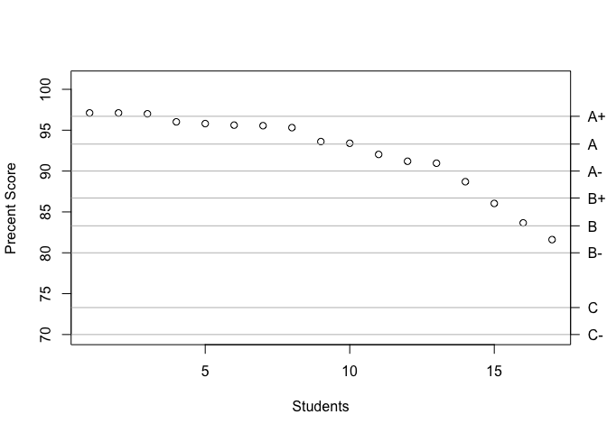

```r
plot(sort(precent, decreasing=T), ylim=c(70,101), ylab="Precent Score", xlab="Students")
letter.grades <- c("C-"=70,
                   "C"=73.3,
                   "B-"=80,
                   "B"=83.3,
                   "B+"=86.7,
                   "A-"=90,
                   "A"=93.3,
                   "A+"=96.7)

abline(h=letter.grades, col="gray")
axis(4, at=letter.grades, labels=names(letter.grades), las=2)
```

# 5 Grades

Now finally assign grades

```r
grades <- cut(
  precent,
  breaks = c(letter.grades,100),
  labels = names(letter.grades))

#cbind(precent,as.character(grades))
x <- cbind( round(precent,2), as.character(grades) )
x
```

```
##    [,1]    [,2]
## 1  "95.62" "A"
## 2  "88.7"  "B+"
## 3  "93.61" "A"
## 4  "93.4"  "A"
## 5  "91.2"  "A-"
## 6  "97.11" "A+"
## 7  "97.11" "A+"
## 8  "81.61" "B-"
## 9  "92.03" "A-"
## 10 "86.04" "B"
## 11 "96.02" "A"
## 12 "97.01" "A+"
## 13 "95.31" "A"
## 14 "83.66" "B"
## 15 "95.55" "A"
## 16 "90.96" "A-"
## 17 "95.81" "A"
```

And how many of each grade do we have?

```r
table(grades)
```

```
## grades
## C-  C B-  B B+ A-  A A+
##  0  0  1  2  1  3  7  3
```

And our final result

```r
# Put humpty-dumpty back togeter again
a <- d[,1:3]
a$Precent=c(round(precent,2),100)
a$Grade=c(as.character(grades),NA)
a <- cbind(a, d[,4:16])
#a # dont print out ;-)
```

Output for students to see (we exclude their email’s and name’s here but keep their exam numnber)

```r
# Put humpty-dumpty back togeter again
#b$PID <- d$PID
b <- d[,1, drop=FALSE]
b$Precent <- c(round(precent,2),100)
b$Grade <- c(as.character(grades),NA)
b <- cbind(b, d[,4:16])
b
```

| PID | Precent | Grade | Alignment..Due.1.18. | HW.Quiz.1..Due.1.16. | HW.Quiz.2..Due.1.16. | DataCamp..Orientation..Due.1.23. | DataCamp..Intro.to.R..Due.1.25. | DataCamp..Reporting..Due.1.25. | DataCamp..Functions..Due.1.25. | DataCamp..Loops..Due.1.25. | DataCamp..Utilities..Due.2.5. | DataCamp..The.Apply.Family..Due.2.5. | Q6..Bio3D.Function | Final_Projects | Final_Exam |
| --- | --- | --- | --- | --- | --- | --- | --- | --- | --- | --- | --- | --- | --- | --- | --- |
| A13712899 | 95.62 | A | 10 | 13 | 13 | 5 | 10 | 5.0 | 5.0 | 5.0 | 5.0 | 5.0 | 10 | 44 | 75 |
| A15362722 | 88.70 | B+ | 10 | 13 | 14 | 5 | 10 | 2.5 | 2.5 | 2.5 | 2.5 | 2.5 | 10 | 45 | 70 |
| A13513679 | 93.61 | A | 10 | 14 | 14 | 5 | 10 | 5.0 | 5.0 | 5.0 | 5.0 | 5.0 | 10 | 44 | 70 |
| A12240237 | 93.40 | A | 10 | 15 | 14 | 5 | 10 | 5.0 | 5.0 | 5.0 | 5.0 | 5.0 | 10 | 44 | 69 |
| A91051907 | 91.20 | A- | 10 | 15 | 14 | 5 | 10 | 5.0 | 5.0 | 5.0 | 5.0 | 5.0 | 10 | 44 | 65 |
| A11934008 | 97.11 | A+ | 10 | 13 | 14 | 5 | 10 | 5.0 | 5.0 | 5.0 | 5.0 | 5.0 | 10 | 44 | 77 |
| A11934013 | 97.11 | A+ | 10 | 13 | 14 | 5 | 10 | 5.0 | 5.0 | 5.0 | 5.0 | 5.0 | 10 | 44 | 77 |
| A12320490 | 81.61 | B- | 10 | 15 | 13 | 5 | 10 | 5.0 | 5.0 | 5.0 | 5.0 | 5.0 | 9 | 42 | 51 |
| A14549640 | 92.03 | A- | 10 | 13 | 12 | 5 | 10 | 5.0 | 5.0 | 5.0 | 5.0 | 5.0 | 9 | 44 | 70 |
| A11315803 | 86.04 | B | 10 | 10 | 13 | 5 | 10 | 5.0 | 5.0 | 5.0 | 5.0 | 5.0 | 10 | 44 | 60 |

[output cut: 8 more lines]